# Writing functions in R

## Writing functions in R: setup

Before we start, make sure you’ve:

1. Got access to the `alpha-r-training` bucket
2. Cloned the writing_functions_in_r repo into your RStudio
3. Pulled any changes (the blue arrow on the Git tab in the top right panel)
4. Got `example_code.R` open in RStudio
5. Run the command `renv::restore()` in the RStudio console to make sure you have the required packages installed
6. Opened the writing_functions_in_r repo on GitHub, so you can refer to the README

If you need any help, just ask! We will be monitoring the Teams chat throughout the session.

## Agenda

| Item | Time |
| --- | --- |
| Set up and introduction | 10:00 - 10:10 |
| Examples of basic functions (including exercises) | 10:10 - 11:20 |
| Break | 11:20 - 11:30 |
| ‘Real-world’ example functions (including exercises) | 11:30 - 12:45 |
| Hints and tips | 12:45 - 13:00 |

## Learning outcomes

### By the end of this session you should know:

- How to write a basic function.
- The circumstances when you might want to consider writing a function.
- Why using functions is beneficial.
- The best practice for writing functions.
- Where to go for more information on some of the topics touched on in this course.

### Before we start

To follow along with the code run during this session and participate in the exercises, open the script “example_code.R” in RStudio. All the code that we’ll show in this session is stored in “example_code.R”, and you can edit this script to write solutions to the exercises. You may also want to have the course [README](https://github.com/moj-analytical-services/writing_functions_in_r) open as a reference.

### A note on the examples given in this course

During this session we’ll show lots of examples of functions. Depending on how experienced you are with using R, some of these examples may introduce new concepts that are not the focus of this course. It is not required that you have prior knowledge of these concepts, as they are included only to demonstrate possible uses for functions when undertaking typical programming tasks in Data & Analysis. One of the purposes of the examples is to provide a resource that can be referred back to in the future.

## What is a function?

Functions are a way to bundle up bits of code to make them easy to reuse. Base R includes numerous built-in functions and there are thousands more R functions in packages available on CRAN and elsewhere.

Here is an example of one of the built-in R functions, `sum()`:

```r
x <- c(1, 2, 3, 4, 5) # Create a vector of numbers to sum
sum(x) # Sum the numbers contained in 'x'
```

```
> [1] 15
```

You can also write your own functions, called “user-defined functions”.

Functions in a package are the same thing as functions you define yourself, they’re just stored in a different way.

## Why use functions?

### Code maintenance

Generally functions are used to automate common tasks, to avoid copying and pasting the same code multiple times with minor alterations. While writing a function has a small up front cost, you’ll reap the benefits when you need to make changes to your code, and your QA’er will also thank you, as they’ll only need to check your function works once!

### Abstraction

One of the benefits of functions is they abstract away the details of *how* the code works. To use a function, all you need to understand is *what* the function is designed to do. You’ll need to understand how your function works when you’re writing it of course, but you won’t need to think about it every time you use it.

### Code legibility

You can use functions to make your code better structured and easier to read - done well, this can make your code a lot easier to understand for someone unfamiliar with it, or even yourself a few months down the line.

## How to write a function

The syntax for creating a function is:

```r
# Comment describing what the function does
function_name <- function(arg1, arg2) {
  # function body, e.g.
  paste(arg1, arg2, "!")
}
```

We use `function()` to create a function and assign it to the object `function_name`.

A function is made up of three components:

- Its **arguments** (in this example, `arg1` and `arg2`) - these are variables used inside the function body which we can set each time we call the function.
- The function **body** (everything between the curly brackets) - this is where we put the code.
- And the function **environment** (where the function was created) - this determines what variables and other functions it has access to. You can find out more about environments [here](https://r4ds.had.co.nz/functions.html#environment).

## Examples of basic functions

## Example 1: a very basic function

Here’s an example of a very basic user-defined function, called `add_two()`, that takes `x` as an argument:

```r
# This function takes the argument 'x', and adds 2 to it
add_two <- function(x) {

  x + 2

}
```

R will automatically return the value of the last evaluated expression. There is also a `return()` function. More on where to use this later.

Let’s try using the function `add_two()`:

```r
# Calling the function by itself prints the result to the console
add_two(3)
```

```
> [1] 5
```

```r
# Alternatively the result can be saved as a new variable
result <- add_two(3)
result
```

```
> [1] 5
```

Note: before you can use a function you need to run the code to create it.

## Example 2: multiple inputs

Functions can accept as many arguments as you like, but can only output one object (if it is necessary to output more than one object, then the desired outputs can be combined together into a list, and the list can be returned). Here’s a function that requires two input variables:

```r
# This function sums the squares of two numbers
sum_squares <- function(x, y) {

  x^2 + y^2

}

sum_squares(3, y = 5)
```

```
> [1] 34
```

When you call a function, you can specify the arguments by position or name. In this example, the function accepts arguments called `x` and `y`, with the order specified as `x` then `y` in the function definition. Therefore when `sum_squares(3, 5)` is called, the arguments are interpreted as `x = 3` and `y = 5`. Alternatively, if we called `sum_squares(5, 3)` then the arguments would be interpreted as `x = 5` and `y = 3`.

For more complicated functions with lots of arguments, specifying the arguments by position becomes more error-prone and harder to understand. For home-made functions you should always provide the names of all arguments (except potentially the first one if it is in first place), then the order of the arguments doesn’t matter:

```r
# Good
sum_squares(3, y = 5)
```

```
> [1] 34
```

```r
# Acceptable
sum_squares(y = 5, x = 3)
```

```
> [1] 34
```

```r
# Bad
sum_squares(3, 5)
```

```
> [1] 34
```

## Exercises

Let’s start with some simple exercises to get familiar with the syntax of writing functions.

### 1.1 hello_world()

Create a function called `hello_world` which prints “Hello world!” to the console, and call the function.

### 1.2 my_mean()

Create a function called `my_mean` which takes two arguments, `x` and `y`, and calculates their mean. Call the function to find the mean of 7.5 and 16.

```r
# 1.1 hello_world() solution

hello_world <- function() {
  print("Hello world!")
}

hello_world()
```

```
> [1] "Hello world!"
```

```r
# 1.2 my_mean() solution

my_mean <- function(x, y) {
  (x + y) / 2
}

my_mean(7.5, 16)
```

```
> [1] 11.75
```

## Example 3: conditional statements in functions

Functions can return different outputs depending on some condition. In this function the condition is `x < 0`, and the condition evaluates to either `TRUE` or `FALSE`:

```r
# This function returns the absolute value of a number
abs_x <- function(x) {
  if (x < 0) {
    return(-x)
  } else {
    return(x)
  }
}

abs_x(-5)
```

```
> [1] 5
```

As soon as a `return()` statement is encountered in a function, the function finishes and returns the variable in the `return()` statement. In the above example, `return()` is used twice as there is a condition with two possibilities. Either the input argument `x` is less than zero, in which case the function ends with the `return(-x)` statement, otherwise if `x` is not less than zero then the function continues to the `return(x)` statement.

## Example 4: functions with side-effects

A function side-effect can be thought of as any change to the workspace that the function makes other than the object that it returns. This can include printing, plotting a chart, saving a file, or modifying a variable in the wider environment. The side-effect is often the main purpose of the function, and in this case the function doesn’t need to return any value. This function has the side-effect of printing a message to the console, depending on the value of the object:

```r
# This function lets you know whether a number is odd or even
odd_or_even <- function(x) {

  if ((x %% 2) == 0) {
    print("The number is even.")
  } else if ((x %% 2) == 1) {
    print("The number is odd.")
  }

}

odd_or_even(x = 4)
```

```
> [1] "The number is even."
```

**Note:** It’s best practice for your function to either return an object or have a side-effect, but not both (with the exception of simple print statements).

## Example 5: errors and warnings

Sometimes it can be useful to include helpful error messages in functions, e.g. by anticipating the sorts of variables that could be input. What happens if you try to use a non-integer or a string as an argument in the previous example? Try the running the function with the following arguments:

```r
odd_or_even(x = 1.5)
odd_or_even(x = "a")
```

```
> Error in x%%2: non-numeric argument to binary operator
```

```r
odd_or_even(x = c(1, 2, 3))
```

```
> Warning in if ((x%%2) == 0) {: the condition has length > 1 and only the first
> element will be used
```

```
> Warning in if ((x%%2) == 1) {: the condition has length > 1 and only the first
> element will be used
```

```
> [1] "The number is odd."
```

Here’s an adapted version of the function, with some more informative error messages built in using the `stop()` function:

```r
# This function lets you know whether a number is odd or even
odd_or_even <- function(x) {

  if (length(x) > 1){
    stop("x must have length 1.")
  } else if (!is.numeric(x)){
    stop("x must be a number.")
  } else if ((x %% 2) == 0) {
    print("The number is even.")
  } else if ((x %% 2) == 1) {
    print("The number is odd.")
  } else if((x %% 2) != 0 & (x %% 2) != 1){
    stop("x must be an integer.")
  }

}
```

Now try passing some incompatible arguments to the function:

```r
odd_or_even(x = 1.5)
```

```
> Error in odd_or_even(x = 1.5): x must be an integer.
```

```r
odd_or_even(x = "a")
```

```
> Error in odd_or_even(x = "a"): x must be a number.
```

```r
odd_or_even(x = c(1, 2, 3))
```

```
> Error in odd_or_even(x = c(1, 2, 3)): x must have length 1.
```

`stop()` halts execution of the function and prints an error message to the console. Alternatively you can use `warning()`, which prints a warning message to the console but does not stop execution of the function.

## Example 6: optional arguments

Here’s an example of how to include optional arguments, where in this case the optional argument is called `y`:

```r
# This function either returns the sum of two numbers, or returns the argument if only one is supplied
add_a_number <- function(x, y = NULL) {

  if (!is.null(y)) {
    return(x + y)
  } else {
    return(x)
  }

}

add_a_number(x = 6)
```

```
> [1] 6
```

```r
add_a_number(x = 6, y = 7)
```

```
> [1] 13
```

## Example 7: arguments with default values

Any value can be used as a default value for an argument. For example, we can generalise the `sum_squares()` function by allowing it to sum together two numbers raised to any power, but with a default power of 2:

```r
# This function returns the sum of two numbers raised to a particular power (with a default of 2)
sum_powers <- function(x, y, z = 2) {

  x ^ z + y ^ z

}

sum_powers(x = 3, y = 5)
```

```
> [1] 34
```

```r
sum_powers(x = 3, y = 5, z = 3)
```

```
> [1] 152
```

## Exercises

### 2.1 fizz_buzz()

Now try using an if else statement inside a function. Create a function called `fizz_buzz()` which takes a number as input and:

- If the number is divisible by both 3 and 5, returns “fizz buzz”
- If the number is divisible by just 3, returns “fizz”
- If the number is divisible by just 5, returns “buzz”
- Otherwise the number is returned (coerced to character type using `as.character()`)

Try it out with values 1, 2, 3, 5 & 15.

**Hints:**

- This exercise is very similar to example 4. The structure of an if-else statement is:

```
if (condition_1) {
code
} else if (condition_2) {
code
} else {
code
}
```

- To test whether a number is divisible by another number, you can use the modulus operator `%%`, which calculates the remainder. E.g. `1 %% 3 == 0` evaluates to `FALSE`.
- To find out more about if statements and conditional execution, see [here](https://r4ds.had.co.nz/functions.html#conditional-execution)

```r
# 2.1 fizz_buzz() solution

fizz_buzz <- function(x) {

  if (x %% 3 == 0 & x %% 5 == 0) {
    return("fizz buzz")
  } else if (x %% 3 == 0) {
    return("fizz")
  } else if (x %% 5 == 0) {
    return("buzz")
  } else {
    return(as.character(x))
  }

}
```

```r
fizz_buzz(1)  # "1"
fizz_buzz(2)  # "2"
fizz_buzz(3)  # "fizz"
fizz_buzz(5)  # "buzz"
fizz_buzz(15) # "fizz buzz"
```

### 2.2 fizz_buzz_vec()

Most functions in R are vectorised. This means they can apply an operation to every element of a vector at the same time. It’s best practice to vectorise your own functions too as this will help you to apply them to data sets and combine them with other functions.

Create a new version of the `fizz_buzz()` function called `fizz_buzz_vec` which instead accepts a vector of numbers. Test it out on a vector of the numbers 1 to 15.

**Hint:** the function `case_when()` from the Tidyverse package `dplyr` is really useful when you want to vectorise multiple if-else statements, each with a different desired outcome. Run `?case_when` to bring up the help file.

*This exercise is a bit tricky - if you get stuck, you can still complete exercise 2.3.*

```r
# 2.2 fizz_buzz_vec() solution

fizz_buzz_vec <- function(x) {

  dplyr::case_when(
    x %% 3 == 0 & x %% 5 == 0 ~ "fizz buzz",
    x %% 3 == 0 ~ "fizz",
    x %% 5 == 0 ~ "buzz",
    TRUE ~ as.character(x)
  )

}

fizz_buzz_vec(1:15)
```

```
>  [1] "1"         "2"         "fizz"      "4"         "buzz"      "fizz"
>  [7] "7"         "8"         "fizz"      "buzz"      "11"        "fizz"
> [13] "13"        "14"        "fizz buzz"
```

### 2.3 fizz_buzz_custom()

Create a version of `fizz_buzz()` or `fizz_buzz_vec()` called `fizz_buzz_custom()` or `fizz_buzz_custom_vec()` where the values for when to say “fizz” and “buzz” can be changed by setting arguments `fizz` and `buzz`, but the default values are still 3 and 5.

Test your new function out, first by checking you get the same results as above when you don’t specify the `fizz` or `buzz` arguments, and second when you set `buzz = 7` for values 1, 2, 3, 7, 15 and 21.

```r
# 2.3 fizz_buzz_custom() solution

fizz_buzz_custom <- function(x, fizz = 3, buzz = 5) {

  if (x %% fizz == 0 & x %% buzz == 0) {
    return("fizz buzz")
  } else if (x %% fizz == 0) {
    return("fizz")
  } else if (x %% buzz == 0) {
    return("buzz")
  } else {
    return(as.character(x))
  }

}


fizz_buzz_custom_vec <- function(x, fizz = 3, buzz = 5) {

  dplyr::case_when(
    x %% fizz == 0 & x %% buzz == 0 ~ "fizz buzz",
    x %% fizz == 0 ~ "fizz",
    x %% buzz == 0 ~ "buzz",
    TRUE ~ as.character(x)
  )

}
```

```r
fizz_buzz_custom_vec(1:15)
```

```
>  [1] "1"         "2"         "fizz"      "4"         "buzz"      "fizz"
>  [7] "7"         "8"         "fizz"      "buzz"      "11"        "fizz"
> [13] "13"        "14"        "fizz buzz"
```

```r
fizz_buzz_custom_vec(c(1, 2, 3, 7, 15, 21), buzz = 7)
```

```
> [1] "1"         "2"         "fizz"      "buzz"      "fizz"      "fizz buzz"
```

## Example 8: the ellipsis argument

Sometimes being able to pass an arbitrary number of arguments can be useful, especially when another function is called within a wrapper function. This requires the ellipsis construct, `...`, which is designed to pass a variable number of arguments to a function. Here’s an example:

```r
# This function produces a plot of x vs y
plot_x_and_y <- function(x, y, ...) {

  plot(x, y, ...)

}

x <- 1:10
y <- (1:10) * 2
```

The function can be called with only the required arguments:

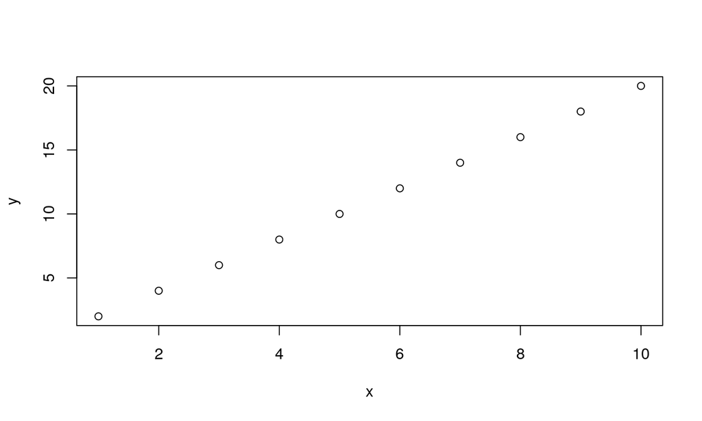

```r
plot_x_and_y(x, y)
```

Or the function can be called with any optional arguments accepted by the plot function:

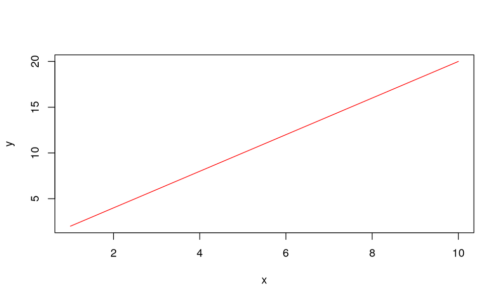

```r
plot_x_and_y(x, y, col='red', type='l')
```

## “Real-world” example functions

## “Real-world” example functions

This section builds on material covered in the [Intro R Training](https://github.com/moj-analytical-services/IntroRTraining) course and makes use of the `dplyr` package, which is a commonly used R package for data manipulation. In the following examples we’ll see how user-defined functions can be used to help with cleaning, summarising, and plotting data. The data we’ll use is from the Criminal Justice System Statistics quarterly publication: December 2018 (published in May 2019), which can be found [here](https://www.gov.uk/government/statistics/criminal-justice-system-statistics-quarterly-december-2018).

Over the course of this section we’ll be tackling some exercises that fit into a data processing story, so make sure you run the code in “example_code.R” as we go along.

## Packages

For these examples we will be using a few packages:

- [`Rs3tools`](https://github.com/moj-analytical-services/Rs3tools) to fetch data from s3.
- `dplyr` is the package we’ll use to create summary tables from the data.
- `stringr` provides functions that can be used to manipulate strings.
- `ggplot2` to create charts.

We will use `package::function()` syntax throughout this course instead of `library()` calls. This makes it easier to see where functions come from, avoids “function masking” and improves the reproducibility and reusability of code. This is particularly important within the body of a function. If a dependency has not been attached to the search list at run time, you will get a probably very unhelpful error message (or your code might use the wrong function).

For a similar reason we are using the R native pipe `|>` rather than the `magrittr` one. (If you are using R < 4.1.0 you will need to replace the native pipe with `%>%`.)

## Examples why you should avoid `library()` calls

Which of the following would you rather have to deal with? A missing function from *somewhere*; a missing but *known* package; or a missing function from a *known* package?

```
> bar()
Error in bar() : could not find function "bar"

> foo::bar()
Error in loadNamespace(x) : there is no package called ‘foo’

> dplyr::bar()
Error: 'bar' is not an exported object from 'namespace:dplyr'
```

Even worse, your code might silently give the wrong result if you are relying on the user having made the “correct” `library()` calls.

```r
iris_by_species_1 <- function(species) {
  datasets::iris |> filter(iris[[5]] == species) |> dplyr::glimpse()
}

iris_by_species_2 <- function(species) {
  datasets::iris |> dplyr::filter(iris[[5]] == species) |> dplyr::glimpse()
}

iris_by_species_1("setosa")
```

```
>  Time-Series [1:150, 1:5] from 1 to 150: NA NA NA NA NA NA NA NA NA NA ...
```

```r
iris_by_species_2("setosa")
```

```
> Rows: 50
> Columns: 5
> $ Sepal.Length <dbl> 5.1, 4.9, 4.7, 4.6, 5.0, 5.4, 4.6, 5.0, 4.4, 4.9, 5.4, 4.…
> $ Sepal.Width  <dbl> 3.5, 3.0, 3.2, 3.1, 3.6, 3.9, 3.4, 3.4, 2.9, 3.1, 3.7, 3.…
> $ Petal.Length <dbl> 1.4, 1.4, 1.3, 1.5, 1.4, 1.7, 1.4, 1.5, 1.4, 1.5, 1.5, 1.…
> $ Petal.Width  <dbl> 0.2, 0.2, 0.2, 0.2, 0.2, 0.4, 0.3, 0.2, 0.2, 0.1, 0.2, 0.…
> $ Species      <fct> setosa, setosa, setosa, setosa, setosa, setosa, setosa, s…
```

## Fetching data

Here we are reading in a copy of the `Prosecutions and Convictions` dataset from s3 and storing the dataframe as a variable called `prosecutions_and_convictions`. In the second step we’re filtering the dataset to extract only the prosecutions and saving to another variable, named `prosecutions`.

```r
prosecutions_and_convictions <- Rs3tools::read_using(
  FUN = read.csv,
  s3_path = "s3://alpha-r-training/writing-functions-in-r/prosecutions-and-convictions-2018.csv"
)

# Filter for Magistrates Court to extract the prosecutions
prosecutions <- prosecutions_and_convictions |>
  dplyr::filter(`Court.Type` == "Magistrates Court")
```

Here’s a preview of the data stored in `prosecutions`:

```r
dplyr::glimpse(prosecutions)
```

```
> Rows: 107,493
> Columns: 16
> $ Year                      <int> 2008, 2008, 2008, 2008, 2008, 2008, 2008, 20…
> $ Quarter                   <chr> "Q1", "Q1", "Q1", "Q1", "Q1", "Q1", "Q1", "Q…
> $ Sex                       <chr> "01: Male", "01: Male", "01: Male", "01: Mal…
> $ Type.of.Defendent         <chr> "01: Person", "01: Person", "01: Person", "0…
> $ Age.Group                 <chr> "01: Juveniles", "01: Juveniles", "01: Juven…
> $ Age.Range                 <chr> "01: 10-11", "01: 10-11", "01: 10-11", "01: …
> $ Ethnicity                 <chr> "N/A", "N/A", "N/A", "N/A", "N/A", "N/A", "N…
> $ Court.Type                <chr> "Magistrates Court", "Magistrates Court", "M…
> $ Offence.Type              <chr> "01 Indictable only", "01 Indictable only", …
> $ Offence.Group             <chr> "02 Sexual offences", "03 Robbery", "03 Robb…
> $ Tried                     <chr> "5: Not tried", "01: Tried at magistrates co…
> $ Plea.at.the.Crown.Court   <chr> "N/A", "N/A", "N/A", "N/A", "N/A", "N/A", "N…
> $ Convicted..Not.convicted  <chr> "02: Not convicted", "01: Convicted", "02: N…
> $ Sentenced...Not.sentenced <chr> "02: Not sentenced", "01: Sentenced", "02: N…
> $ Outcome                   <chr> "01: Proceedings terminated early", "07: Fou…
> $ Count                     <int> 1, 6, 1, 1, 10, 1, 1, 1, 31, 1, 3, 15, 1, 5,…
```

## Cleaning data

After reading in a dataframe it can often be helpful to standardise the column headings. Below is an example of a function that could be used for this purpose. It takes a vector of strings as the argument, ensures all letters in the string vector are lower-case, and makes use of “regular expressions” or “regex” to find and replace all spaces and punctuation marks with an underscore:

```r
# This function standardises strings contained in a vector
generalise_names <- function(names) {

  names |>
    # Convert any uppercase letters to lowercase
    tolower() |>
    # Trim any blank spaces at the start or end of each string
    stringr::str_trim() |>
    # Replace anything that isn't a letter or number with an underscore
    stringr::str_replace_all(pattern = "[^A-Za-z0-9]", replacement = "_") |>
    # Remove repeated underscores
    stringr::str_remove_all(pattern = "(?<=_)_+") |>
    # Remove any underscore at the beginning or end of the string
    stringr::str_remove_all(pattern = "^_|_$")

}
```

Here is a demonstration of how functions such as this can be useful:

```r
names <- c("Option 1", "   Option (1)", "Option: 1", "option 1", "OPTION - 1")
generalise_names(names)
```

```
> [1] "option_1" "option_1" "option_1" "option_1" "option_1"
```

The [`stringr` cheatsheet](https://stringr.tidyverse.org/#cheatsheet) is a great resource for learning more about regular expressions.

### Exercise 3

Use the `generalise_names()` function defined above to clean the column headings of the `prosecutions` dataset. Add your solution to the script “example_code.R”, underneath the line with the command `generalise_names(names)`.

**Hint:** use the function `colnames()` to retrieve the column headings of the dataset as a vector.

```r
# Exercise 3 solution

colnames(prosecutions) <- colnames(prosecutions) |> generalise_names()
dplyr::glimpse(prosecutions)
```

```
> Rows: 107,493
> Columns: 16
> $ year                    <int> 2008, 2008, 2008, 2008, 2008, 2008, 2008, 2008…
> $ quarter                 <chr> "Q1", "Q1", "Q1", "Q1", "Q1", "Q1", "Q1", "Q1"…
> $ sex                     <chr> "01: Male", "01: Male", "01: Male", "01: Male"…
> $ type_of_defendent       <chr> "01: Person", "01: Person", "01: Person", "01:…
> $ age_group               <chr> "01: Juveniles", "01: Juveniles", "01: Juvenil…
> $ age_range               <chr> "01: 10-11", "01: 10-11", "01: 10-11", "01: 10…
> $ ethnicity               <chr> "N/A", "N/A", "N/A", "N/A", "N/A", "N/A", "N/A…
> $ court_type              <chr> "Magistrates Court", "Magistrates Court", "Mag…
> $ offence_type            <chr> "01 Indictable only", "01 Indictable only", "0…
> $ offence_group           <chr> "02 Sexual offences", "03 Robbery", "03 Robber…
> $ tried                   <chr> "5: Not tried", "01: Tried at magistrates cour…
> $ plea_at_the_crown_court <chr> "N/A", "N/A", "N/A", "N/A", "N/A", "N/A", "N/A…
> $ convicted_not_convicted <chr> "02: Not convicted", "01: Convicted", "02: Not…
> $ sentenced_not_sentenced <chr> "02: Not sentenced", "01: Sentenced", "02: Not…
> $ outcome                 <chr> "01: Proceedings terminated early", "07: Found…
> $ count                   <int> 1, 6, 1, 1, 10, 1, 1, 1, 31, 1, 3, 15, 1, 5, 2…
```

In this dataset, some of the columns contain values with a number along with a category; for example, the `age_group` column contains categories like “01: Juveniles” rather than just “Juveniles”.

[output not shown]

These numbers might be undesirable, so we can write a function like this to remove them:

```r
# This function removes patterns at the start of a string that are:
# 1 or 2 digits followed by any number of colons and/or spaces

remove_numbering <- function(x) {
  stringr::str_remove(x, pattern = "^\\d{1,2}\\s*:*\\s*")
}
```

Here is a demonstration of what this is doing:

```r
some_strings <- c("01 :foo", "01 foo", "01: foo", "01  :  foo", "foo", "bar foo")
remove_numbering(some_strings)
```

```
> [1] "foo"     "foo"     "foo"     "foo"     "foo"     "bar foo"
```

The [`stringr` cheatsheet](https://stringr.tidyverse.org/#cheatsheet) is a great resource for learning more about regular expressions.

Then we can use the `mutate()` function with the `across()` function from `dplyr`, and the `where()` selection helper from `tidyselect`, to apply the `remove_numbering()` function to columns in the `prosecutions` dataframe. The `dplyr::mutate()` function will apply the specified function to all columns where a particular condition is met, and in this case the condition `is.character` requires that the column contains strings.

```r
prosecutions <- dplyr::mutate(prosecutions, across(where(is.character), remove_numbering))
dplyr::glimpse(prosecutions)
```

```
> Rows: 107,493
> Columns: 16
> $ year                    <int> 2008, 2008, 2008, 2008, 2008, 2008, 2008, 2008…
> $ quarter                 <chr> "Q1", "Q1", "Q1", "Q1", "Q1", "Q1", "Q1", "Q1"…
> $ sex                     <chr> "Male", "Male", "Male", "Male", "Male", "Male"…
> $ type_of_defendent       <chr> "Person", "Person", "Person", "Person", "Perso…
> $ age_group               <chr> "Juveniles", "Juveniles", "Juveniles", "Juveni…
> $ age_range               <chr> "10-11", "10-11", "10-11", "10-11", "10-11", "…
> $ ethnicity               <chr> "N/A", "N/A", "N/A", "N/A", "N/A", "N/A", "N/A…
> $ court_type              <chr> "Magistrates Court", "Magistrates Court", "Mag…
> $ offence_type            <chr> "Indictable only", "Indictable only", "Indicta…
> $ offence_group           <chr> "Sexual offences", "Robbery", "Robbery", "Poss…
> $ tried                   <chr> "Not tried", "Tried at magistrates court", "Tr…
> $ plea_at_the_crown_court <chr> "N/A", "N/A", "N/A", "N/A", "N/A", "N/A", "N/A…
> $ convicted_not_convicted <chr> "Not convicted", "Convicted", "Not convicted",…
> $ sentenced_not_sentenced <chr> "Not sentenced", "Sentenced", "Not sentenced",…
> $ outcome                 <chr> "Proceedings terminated early", "Found guilty"…
> $ count                   <int> 1, 6, 1, 1, 10, 1, 1, 1, 31, 1, 3, 15, 1, 5, 2…
```

For the final stage of data cleaning, we can make missing and unknown values more consistent using a function such as the following:

```r
clean_not_known <- function(x,
                            not_known_phrase = "Not known",
                            values_to_change = c("n/a", "not known", "unknown", "not stated")) {

  # Replace any missing (NA) values
  x <- replace(x, is.na(x), not_known_phrase)

  # Remove any white space that might cause the strings to not match
  x <- stringr::str_trim(x)

  # Replace strings in the data that refer to a missing or unknown value.
  dplyr::if_else(tolower(x) %in% values_to_change, not_known_phrase, x)

}
```

In this function we’ve included some default values, so by default any strings that match “n/a”, “not known”, “unknown”, or “not stated” are replaced, and the default replacement value is “Not known”. We’ve used `dplyr::if_else()` as a vectorised form of an if-else statement. It’s similar to `dplyr::case_when()` (which we used in exercise 2.2), but can only be used with one condition and two possible outcomes. We’ve also used the `tolower()` function, which ensures all strings are lower case before searching for the missing/unknown phrases.

```r
prosecutions <- dplyr::mutate(
  prosecutions,
  dplyr::across(
    .cols = tidyselect::where(is.character),
    .fns = clean_not_known
  )
)

dplyr::glimpse(prosecutions)
```

```
> Rows: 107,493
> Columns: 16
> $ year                    <int> 2008, 2008, 2008, 2008, 2008, 2008, 2008, 2008…
> $ quarter                 <chr> "Q1", "Q1", "Q1", "Q1", "Q1", "Q1", "Q1", "Q1"…
> $ sex                     <chr> "Male", "Male", "Male", "Male", "Male", "Male"…
> $ type_of_defendent       <chr> "Person", "Person", "Person", "Person", "Perso…
> $ age_group               <chr> "Juveniles", "Juveniles", "Juveniles", "Juveni…
> $ age_range               <chr> "10-11", "10-11", "10-11", "10-11", "10-11", "…
> $ ethnicity               <chr> "Not known", "Not known", "Not known", "Not kn…
> $ court_type              <chr> "Magistrates Court", "Magistrates Court", "Mag…
> $ offence_type            <chr> "Indictable only", "Indictable only", "Indicta…
> $ offence_group           <chr> "Sexual offences", "Robbery", "Robbery", "Poss…
> $ tried                   <chr> "Not tried", "Tried at magistrates court", "Tr…
> $ plea_at_the_crown_court <chr> "Not known", "Not known", "Not known", "Not kn…
> $ convicted_not_convicted <chr> "Not convicted", "Convicted", "Not convicted",…
> $ sentenced_not_sentenced <chr> "Not sentenced", "Sentenced", "Not sentenced",…
> $ outcome                 <chr> "Proceedings terminated early", "Found guilty"…
> $ count                   <int> 1, 6, 1, 1, 10, 1, 1, 1, 31, 1, 3, 15, 1, 5, 2…
```

### Exercise 4

Modify `clean_not_known()` to make replacing missing (NA) values optional.

### Exercise 5

Write a wrapper function to apply `generalise_names()`, `remove_numbering()`, and `clean_not_known()` to the dataset.

```r
# Exercise 4 solution

clean_not_known <- function(x,
                            not_known_phrase = "Not known",
                            change_na = TRUE,
                            values_to_change = c("n/a", "not known", "unknown", "not stated")) {

  # Replace any missing (NA) values
  if (change_na) {
    x <- replace(x, is.na(x), not_known_phrase)
  }

  # Remove any white space that might cause the strings to not match
  x <- stringr::str_trim(x)

  # Replace strings in the data that refer to a missing or unknown value.
  dplyr::if_else(tolower(x) %in% values_to_change, not_known_phrase, x)

}
```

```r
# Exercise 5 solution

clean_dataset <- function(data) {

  # Clean the column headings
  colnames(data) <- generalise_names(colnames(data))

  # Remove numeric indices from columns
  data <- dplyr::mutate(
    data,
    dplyr::across(
      .cols = tidyselect::where(is.character),
      .fns = remove_numbering
    )
  )

  # Make missing/unknown value entries more consistent
  dplyr::mutate(
    data,
    dplyr::across(
      .cols = tidyselect::where(is.character),
      .fns = clean_not_known
    )
  )

}
```

## Summarising data

Let’s say we wanted to create a summary table showing the number of people prosecuted in different age bands. We could do:

```r
prosecutions_grouped <- prosecutions |>
  dplyr::group_by(age_range) |>
  dplyr::summarise(counts = sum(count))
```

In the above code we are grouping the `prosecutions` dataframe by the categories in the `age_range` column, then summarising the number of prosecutions in each of those categories by summing the `count` column.

The resulting dataframe is saved as a variable called `prosecutions_grouped`.

Notice how the `dplyr` functions `group_by()` and `summarise()` require that the column names are not enclosed in quotation marks, meaning that they are not passed as strings: this behaviour is known as non-standard evaluation, and will be important later.

```r
prosecutions_grouped
```

```
> # A tibble: 14 × 2
>    age_range                       counts
>    <chr>                            <int>
>  1 10-11                             3324
>  2 12-14                           113960
>  3 15-17                           570275
>  4 18-20                          1302589
>  5 21-24                          2131033
>  6 25+ (prior to 2017)           10209264
>  7 25-29 (2017 onwards)            447108
>  8 30-39 (2017 onwards)            758230
>  9 40-49 (2017 onwards)            477217
> 10 50-59 (2017 onwards)            261626
> 11 60+ (2017 onwards)              101554
> 12 Companies, public bodies etc.   114771
> 13 Not known (Adult)               195459
> 14 Not known (Juvenile)               150
```

## Sidenote: standard vs non-standard evaluation

In the plot below how does R know to label the x-axis `foo` and the y-axis `bar` we haven’t explicitly supplied axis labels? The `plot()` function is using standard evaluation to get the values supplied to the x and y axes but is also using non-standard evaluation to get the names of the objects passed to the arguments for use as axis labels.

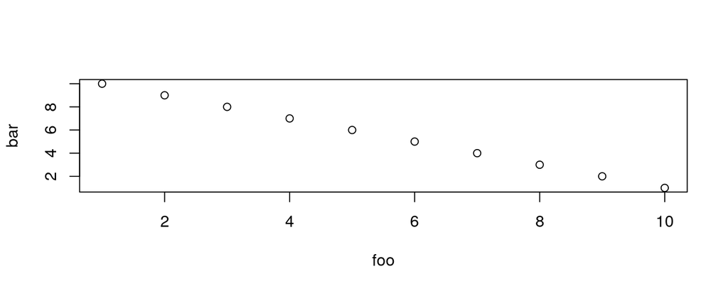

```r
foo <- 1:10
bar <- 10:1
plot(foo, bar)
```

What if we wanted to create several different summary tables? We could write a function to avoid writing this out each time. Following the previous examples in this course, you might expect this function to work:

```r
# This function produces a summary table based on a dataset
sum_group <- function(df, group_col, sum_col) {

  df |>
    dplyr::group_by(group_col) |>
    dplyr::summarise(counts = sum(sum_col))

}
```

However trying to use this function results in an error.

```r
prosecutions_grouped <- sum_group(df = prosecutions, group_col = "age_range", sum_col = "count")
```

```
> Error in `dplyr::group_by()`:
> ! Must group by variables found in `.data`.
> ✖ Column `group_col` is not found.
```

This is because of the non-standard evaluation (NSE) mentioned above. The `dplyr` functions don’t recognise `group_col` and `sum_col` as column names, because they can’t see that these are variables containing the actual column names. While the NSE usually makes the `dplyr` functions more convenient to use, it makes them slightly trickier to use in user-defined functions.

Fortunately there are methods available to help get around the NSE problem. The function below shows an example of how our `sum_group()` function can be modified to accept column names stored as strings, using the `.data` pronoun with `[[]]`.

```r
# This function produces a summary table based on a dataset
sum_group <- function(df, group_col, sum_col) {

  df |>
    dplyr::group_by(.data[[group_col]]) |>
    dplyr::summarise(counts = sum(.data[[sum_col]]))

}
```

```r
prosecutions_grouped <- sum_group(df = prosecutions, group_col = "age_range", sum_col = "count")
prosecutions_grouped
```

```
> # A tibble: 14 × 2
>    age_range                       counts
>    <chr>                            <int>
>  1 10-11                             3324
>  2 12-14                           113960
>  3 15-17                           570275
>  4 18-20                          1302589
>  5 21-24                          2131033
>  6 25+ (prior to 2017)           10209264
>  7 25-29 (2017 onwards)            447108
>  8 30-39 (2017 onwards)            758230
>  9 40-49 (2017 onwards)            477217
> 10 50-59 (2017 onwards)            261626
> 11 60+ (2017 onwards)              101554
> 12 Companies, public bodies etc.   114771
> 13 Not known (Adult)               195459
> 14 Not known (Juvenile)               150
```

## Plotting data

Let’s say we want to produce some plots, and want them all to have the same style. We can define the style of the plot in a function, then we only have to change the styling in one place if it needs changing. This function plots a breakdown of the number of prosecutions over time, with a default breakdown option of `"offence_type"`, and the plot is a line chart with `ggplot2`’s grey theme:

```r
# This function produces a plot of the number of prosecutions over time
plot_prosecutions <- function(df, breakdown = "offence_type") {

  df_grouped <- df |>
    dplyr::group_by(.data[[breakdown]], year) |>
    dplyr::summarise(counts = sum(count), .groups = "keep")

  df_grouped |>
    ggplot2::ggplot(
      ggplot2::aes(x = .data$year,
                   y = .data$counts,
                   group = .data[[breakdown]],
                   col = .data[[breakdown]])
    ) +
    ggplot2::geom_line() +
    ggplot2::scale_x_continuous(breaks = 0:2100) +
    ggplot2::theme_grey()
}
```

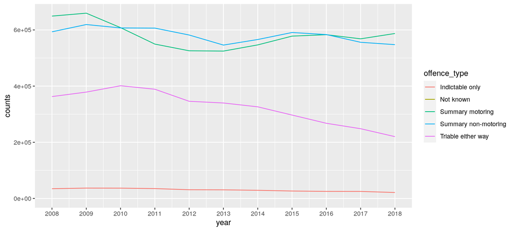

```r
# Call function
plot_prosecutions(prosecutions, breakdown = "offence_type")
```

### Exercise 6

Modify the `plot_prosecutions()` function to use `theme_classic()` as the theme, rather than `theme_grey()`. Produce a plot of the breakdown of the number of prosecutions over time, with a breakdown by `"offence_group"`.

```r
# Exercise 6 solution
plot_prosecutions <- function(df, breakdown = "offence_type") {

  df_grouped <- df |>
    dplyr::group_by(.data[[breakdown]], year) |>
    dplyr::summarise(counts = sum(count), .groups = "keep")

  df_grouped |>
    ggplot2::ggplot(
      ggplot2::aes(x = .data$year,
                   y = .data$counts,
                   group = .data[[breakdown]],
                   col = .data[[breakdown]])
    ) +
    ggplot2::geom_line() +
    ggplot2::scale_x_continuous(breaks = 0:2100) +
    ggplot2::theme_classic()
}
```

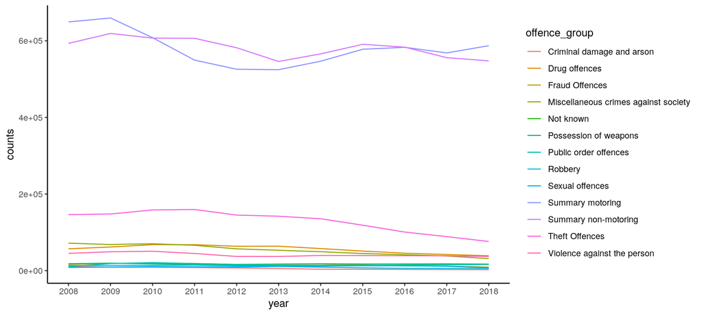

```r
# Exercise 6 solution

plot_prosecutions(prosecutions, breakdown = "offence_group")
```

## Hints and tips

## When to write a function

### When you’ve copied and pasted two times

There is a principal in software engineering called Don’t Repeat Yourself (DRY) - which basically states that you should avoid duplication wherever possible. A good rule of thumb is whenever you find you’ve used the same or similar code in three places, it’s time to consider replacing that code with a function.

### To structure your code

You may also sometimes want to write a function for code you’re only planning to use once as a way of structuring your code and “hiding” some of it to make your main script easier to read.

### When someone hasn’t already written one for you

The R ecosystem is full of high quality packages designed to solve all kinds of problems - it’s generally best to make sure that a function doesn’t already exist before writing your own.

## Best practice

Writing a function is easy, writing a really good function can be a lot harder! Here are a few things to consider:

### Give your function a good name

The name of a function should give you a good idea of what it does. Generally function names should be concise and use verbs rather than nouns.

### Pass variables into the function as arguments

While functions can access objects that haven’t been passed in as an argument, this is generally bad practice as it makes code much harder to understand and modify, and makes the function itself harder to reuse.

### Document your code

You should have comments explaining what your function does, what each argument is, and what it returns.

### Keep it short

A rule of thumb is if all the code for your function doesn’t fit on your screen at the same time, it’s probably too complicated. Consider splitting it up into multiple functions.

### Generalise

Think about whether there are ways you can make your function usable in more situations. For example, is there anything you’re hard-coding that you could set as an argument instead?

### Vectorise by default

R is designed to work well with vectors (e.g. columns of a dataframe). Where possible you should write your function so it can take a vector as an input and apply the transformation to each element. The `generalise_names()` function we looked at is a good example of this!

### Ask for feedback

A key measure of a good function (or any piece of code) is how easy it is for someone else to understand, use and modify it. The best way to test this is to get your code reviewed by someone else.

## How to organise your code

Whenever you’re working on something in R it’s generally best to create an R project and version control your code on GitHub. There’s information on how to do this in the [Analytical Platform guidance](https://user-guidance.services.alpha.mojanalytics.xyz/github.html#creating-your-project-repo-on-github).

It’s also best to keep your functions separate from the rest of your code to make them easier to find.

### Storing your functions in your project

The easiest way to store your functions is just to create a folder in your project called “functions” and save your functions there.

You could either put each function in its own R script with the same name, or you could group related functions into clearly named scripts.

Then just use `source("functions/my_functions_script.R")` (with `functions/` and `my_functions_script.R` replaced with the name of the folder and the name of your script, respectively) to run the code and make your functions available to you in the current session. As with loading packages, it’s best to do this at the top of your script.

Here’s an example of calling a script that contains a new function, called `pick_a_colour()`:

```r
source("functions.R")
```

Now the function is ready to use:

```r
# Create a list of colours to provide to the function
colours <- c("Red", "Blue", "Green", "Magenta", "Cyan", "Yellow", "Purple", "Pink")
pick_a_colour(colours)
```

```
> [1] "Magenta"
```

You can see the code underlying a function by typing its name (without brackets) in the console and hitting “enter”:

```r
pick_a_colour
```

```
> function (colours)
> {
>     x <- sample(1:length(colours), 1)
>     print(colours[x])
> }
```

## Writing a package

An alternative is to make your own package to store your functions, which you can then use like any other R package. There are a few advantages to this:

- It means you (and others) can access your functions from different projects
- There are certain requirements for making R packages that enforce good practice, such as including documentation

This comes at the cost of slightly higher overheads.

A few examples of packages written by people in MoJ are:

- mojchart
- mojrap

To find out more about writing packages, check out the links under further reading.

## Further reading

#### On functions

- [Functions chapter](https://r4ds.had.co.nz/functions.html) of Hadley’s R for Data Science book
- [Functions chapter](https://adv-r.hadley.nz/functions.html) of Hadley’s Advanced R book
- [Tidy Evaluation](https://tidyeval.tidyverse.org/introduction.html) (useful for writing functions which behave like Tidyverse functions)

#### On packages

- [MoJ R package training](https://github.com/moj-analytical-services/rpackage_training)
- [Writing an R package from scratch](https://hilaryparker.com/2014/04/29/writing-an-r-package-from-scratch/)
- Hadley’s [R packages](http://r-pkgs.had.co.nz/) book

#### On loops

- [Iteration chapter](https://r4ds.had.co.nz/iteration.html#dealing-with-failure) of Hadley’s R for Data Science book

#### Misc

- [Tidyverse style guide](https://style.tidyverse.org/) (has some guidance on choosing function and argument names)
- [MoJ coding standards](https://github.com/moj-analytical-services/our-coding-standards)
- [Scoping/environments](https://bookdown.org/rdpeng/rprogdatascience/scoping-rules-of-r.html)

## Get help

If you get stuck, a great place to ask is [ASD slack](https://asdslack.slack.com/) on either the `#r` or `#intro_r` channels.